# R Notebook

Loading all the neccessary libraries

```r
library(mosaic)
library(DataComputing)
library(ggplot2)
library(tidyr)
library(dplyr)
library(tidyverse)
```

# Reaserch Question

#### We wanted to check if there are more males or females affected by heart diseases and what other factors affect heart disease.

# Challenge Encountered

#### The biggest chalenge we faced was data wrangling as it was very hard to decide what variables can be used to make more sense of the data.

# Key Visualisations

### Data preparation

#### Loading the dataset

```r
heart.data <- read.csv("heart.csv")
names(heart.data) <- c( "age", "sex", "cp", "trestbps", "chol","fbs", "restecg",
                   "thalach","exang", "oldpeak","slope", "ca", "thal", "target")
```

A quick glance of the dataset

```r
head(heart.data,5)
```

|  | age | sex | cp | trestbps | chol | fbs | restecg | thalach | exang | oldpeak | slope | ca | thal | target |
| --- | --- | --- | --- | --- | --- | --- | --- | --- | --- | --- | --- | --- | --- | --- |
| 1 | 63 | 1 | 3 | 145 | 233 | 1 | 0 | 150 | 0 | 2.3 | 0 | 0 | 1 | 1 |
| 2 | 37 | 1 | 2 | 130 | 250 | 0 | 1 | 187 | 0 | 3.5 | 0 | 0 | 2 | 1 |
| 3 | 41 | 0 | 1 | 130 | 204 | 0 | 0 | 172 | 0 | 1.4 | 2 | 0 | 2 | 1 |
| 4 | 56 | 1 | 1 | 120 | 236 | 0 | 1 | 178 | 0 | 0.8 | 2 | 0 | 2 | 1 |
| 5 | 57 | 0 | 0 | 120 | 354 | 0 | 1 | 163 | 1 | 0.6 | 2 | 0 | 2 | 1 |

```r
dim(heart.data)
```

```
[1] 303  14
```

## Display The Number Of Rows And Columns

```r
nrow(heart.data )
```

```
[1] 303
```

```r
ncol(heart.data )
```

```
[1] 14
```

## Understanding the datatype of dataset

```r
str(data)
```

```
function (..., list = character(), package = NULL, lib.loc = NULL, verbose = getOption("verbose"),
    envir = .GlobalEnv, overwrite = TRUE)
```

## Display The Summary

```r
summary(heart.data)
```

```
      age             sex               cp           trestbps          chol
 Min.   :29.00   Min.   :0.0000   Min.   :0.000   Min.   : 94.0   Min.   :126.0
 1st Qu.:47.50   1st Qu.:0.0000   1st Qu.:0.000   1st Qu.:120.0   1st Qu.:211.0
 Median :55.00   Median :1.0000   Median :1.000   Median :130.0   Median :240.0
 Mean   :54.37   Mean   :0.6832   Mean   :0.967   Mean   :131.6   Mean   :246.3
 3rd Qu.:61.00   3rd Qu.:1.0000   3rd Qu.:2.000   3rd Qu.:140.0   3rd Qu.:274.5
 Max.   :77.00   Max.   :1.0000   Max.   :3.000   Max.   :200.0   Max.   :564.0
      fbs            restecg          thalach          exang           oldpeak
 Min.   :0.0000   Min.   :0.0000   Min.   : 71.0   Min.   :0.0000   Min.   :0.00
 1st Qu.:0.0000   1st Qu.:0.0000   1st Qu.:133.5   1st Qu.:0.0000   1st Qu.:0.00
 Median :0.0000   Median :1.0000   Median :153.0   Median :0.0000   Median :0.80
 Mean   :0.1485   Mean   :0.5281   Mean   :149.6   Mean   :0.3267   Mean   :1.04
 3rd Qu.:0.0000   3rd Qu.:1.0000   3rd Qu.:166.0   3rd Qu.:1.0000   3rd Qu.:1.60
 Max.   :1.0000   Max.   :2.0000   Max.   :202.0   Max.   :1.0000   Max.   :6.20
     slope             ca              thal           target
 Min.   :0.000   Min.   :0.0000   Min.   :0.000   Min.   :0.0000
 1st Qu.:1.000   1st Qu.:0.0000   1st Qu.:2.000   1st Qu.:0.0000
 Median :1.000   Median :0.0000   Median :2.000   Median :1.0000
 Mean   :1.399   Mean   :0.7294   Mean   :2.314   Mean   :0.5446
 3rd Qu.:2.000   3rd Qu.:1.0000   3rd Qu.:3.000   3rd Qu.:1.0000
 Max.   :2.000   Max.   :4.0000   Max.   :3.000   Max.   :1.0000
```

## Description of Variables

#### target - the predicted attribute - diagnosis of heart disease (angiographic disease status) (Value 0 = < 50% diameter narrowing; Value 1 = > 50% diameter narrowing)

### Converting data from numeric to their respective types

```r
heart <- heart.data %>%
  mutate(sex = if_else(sex == 1, "MALE", "FEMALE"),
         fbs = if_else(fbs == 1, ">120", "<=120"),
         exang = if_else(exang == 1, "YES" ,"NO"),
         cp = if_else(cp == 0, "TYPICAL ANGINA",
                      if_else(cp == 1, "ATYPICAL ANGINA",
                      if_else(cp == 2,"NON-AGINAL PAIN","ASYPMTOMATIC" ))),
         restecg = if_else(restecg == 0, "NORMAL",
                           if_else(restecg == 1, "ABNORMALITY", "PROBABLE OR DEFINITE")),
         slope = as.factor(slope),
         ca = as.factor(ca),
         thal = as.factor(thal),
         target = if_else(target == 1, "YES", "NO")
         ) %>%
  dplyr::select(target, sex, fbs, exang, cp, restecg, slope, ca, thal, everything())
```

### Summary after pre-processing the data

```r
summary(heart)
```

```
    target              sex                fbs               exang
 Length:303         Length:303         Length:303         Length:303
 Class :character   Class :character   Class :character   Class :character
 Mode  :character   Mode  :character   Mode  :character   Mode  :character



      cp              restecg          slope   ca      thal         age
 Length:303         Length:303         0: 21   0:175   0:  2   Min.   :29.00
 Class :character   Class :character   1:140   1: 65   1: 18   1st Qu.:47.50
 Mode  :character   Mode  :character   2:142   2: 38   2:166   Median :55.00
                                               3: 20   3:117   Mean   :54.37
                                               4:  5           3rd Qu.:61.00
                                                               Max.   :77.00
    trestbps          chol          thalach         oldpeak
 Min.   : 94.0   Min.   :126.0   Min.   : 71.0   Min.   :0.00
 1st Qu.:120.0   1st Qu.:211.0   1st Qu.:133.5   1st Qu.:0.00
 Median :130.0   Median :240.0   Median :153.0   Median :0.80
 Mean   :131.6   Mean   :246.3   Mean   :149.6   Mean   :1.04
 3rd Qu.:140.0   3rd Qu.:274.5   3rd Qu.:166.0   3rd Qu.:1.60
 Max.   :200.0   Max.   :564.0   Max.   :202.0   Max.   :6.20
```

### Display The Number Of NAs In Each Column

```r
colSums(is.na(heart))
```

```
  target      sex      fbs    exang       cp  restecg    slope       ca     thal      age
       0        0        0        0        0        0        0        0        0        0
trestbps     chol  thalach  oldpeak
       0        0        0        0
```

### No of females and males in the dataset

```r
heart %>% group_by(sex) %>%
  summarise(count = n())
```

| sex | count |
| --- | --- |
| FEMALE | 96 |
| MALE | 207 |

### Display th average cholestral among sex

```r
heart %>% group_by(sex) %>%
  summarise(avgChol = mean(chol))
```

| sex | avgChol |
| --- | --- |
| FEMALE | 261.3021 |
| MALE | 239.2899 |

### Display if they have high or low risk from the patients cholestral level

```r
LevelOfchol <- function(chol){
  if_else(chol <= 200, "Desirable Chol",
                       if_else(chol <= 239,"Borderline high","High risk"))
}
heart %>% select(sex,age,chol,target) %>%
  mutate(RiskFromChol = LevelOfchol(chol))
```

| sex | age | chol | target | RiskFromChol |
| --- | --- | --- | --- | --- |
| MALE | 63 | 233 | YES | Borderline high |
| MALE | 37 | 250 | YES | High risk |
| FEMALE | 41 | 204 | YES | Borderline high |
| MALE | 56 | 236 | YES | Borderline high |
| FEMALE | 57 | 354 | YES | High risk |
| MALE | 57 | 192 | YES | Desirable Chol |
| FEMALE | 56 | 294 | YES | High risk |
| MALE | 44 | 263 | YES | High risk |
| MALE | 52 | 199 | YES | Desirable Chol |
| MALE | 57 | 168 | YES | Desirable Chol |

[output cut: 293 more lines]

### Average cholestral level among sex dependiing on the resting ecg they have

```r
heart %>% group_by(sex,restecg) %>%
  summarise(avgChol = mean(chol))
```

| sex | restecg | avgChol |
| --- | --- | --- |
| FEMALE | ABNORMALITY | 244.6122 |
| FEMALE | NORMAL | 281.1364 |
| FEMALE | PROBABLE OR DEFINITE | 243.0000 |
| MALE | ABNORMALITY | 233.7767 |
| MALE | NORMAL | 244.0388 |
| MALE | PROBABLE OR DEFINITE | 318.0000 |

### Target variable Analysis

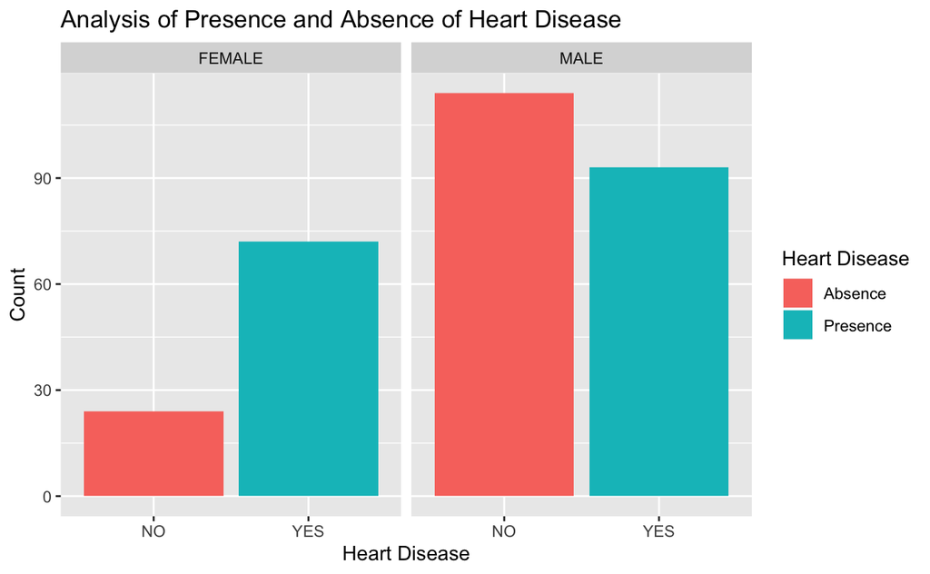

```r
# Bar plot for target (Heart disease)
heart$target <- as.factor(heart$target)
ggplot(heart, aes(x=heart$target, fill=heart$target)) +
  geom_bar() +
  xlab("Heart Disease") +
  ylab("Count") +
  ggtitle("Analysis of Presence and Absence of Heart Disease") +
  scale_fill_discrete(name = "Heart Disease", labels = c("Absence", "Presence"))+
  facet_grid(.~sex)
```

### Presence and absence of heart disease on the whole dataset

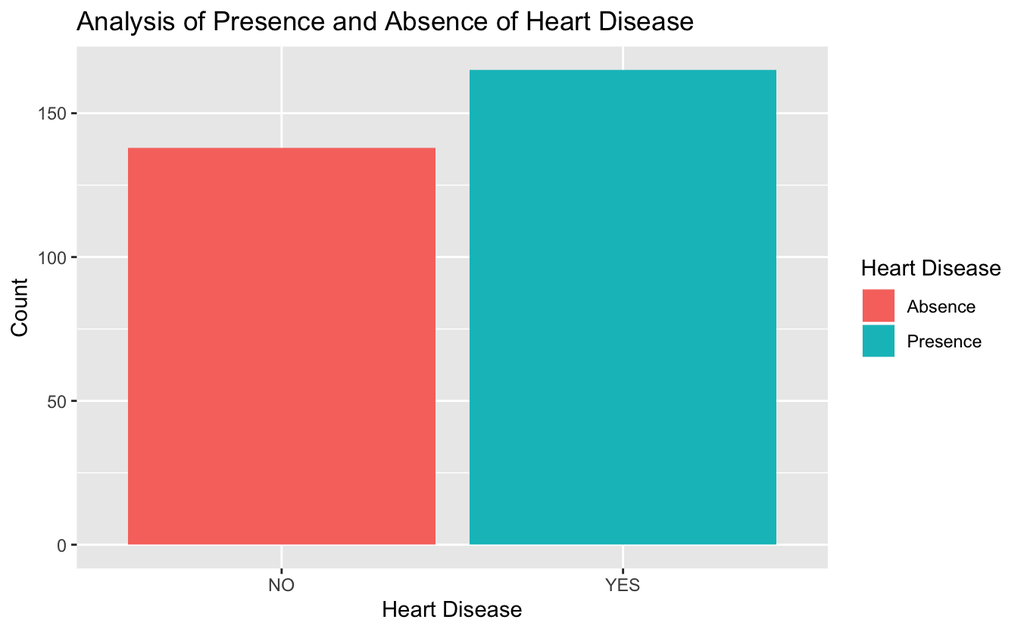

```r
heart$target <- as.factor(heart$target)
ggplot(heart, aes(x=heart$target, fill=heart$target)) +
  geom_bar() +
  xlab("Heart Disease") +
  ylab("Count") +
  ggtitle("Analysis of Presence and Absence of Heart Disease") +
  scale_fill_discrete(name = "Heart Disease", labels = c("Absence", "Presence"))
```

From the above plot, we can observe that the number of people with heart disease is more than with a number of people having no heart disease. We will perform further analysis to find out more about the relevant parameter for the causes of heart diseases.

### Sex vs Cholestrol

#### When there is too much cholesterol in your blood, it builds up in the walls of your arteries, causing a process called atherosclerosis, a form of heart disease.

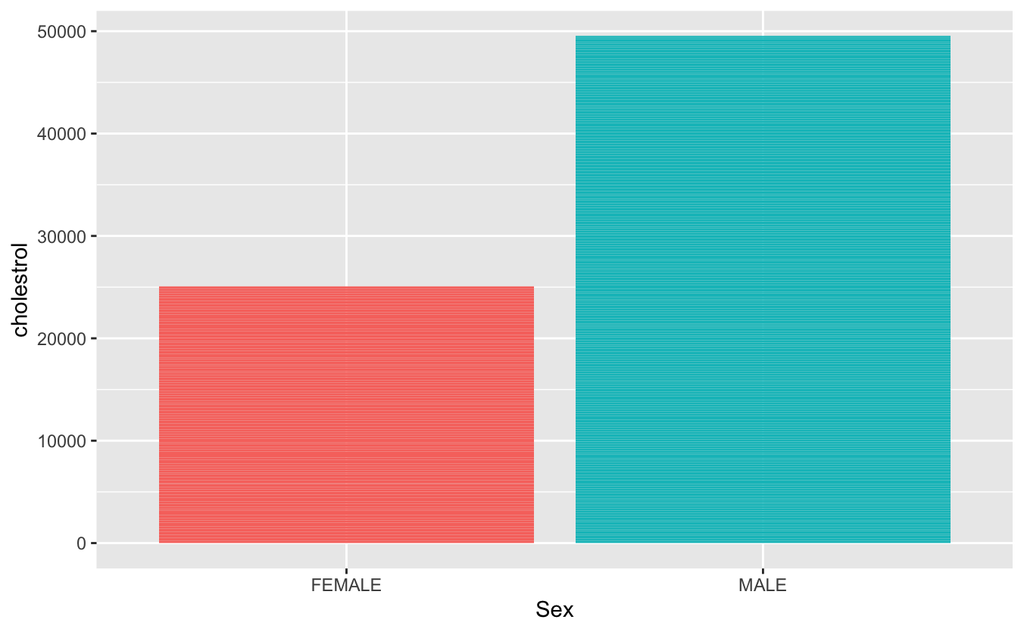

```r
g<-ggplot(data=heart)
g+geom_bar(stat="identity",aes(x=as.factor(heart$sex),y=heart$chol,fill=heart$sex))+xlab("Sex")+ylab("cholestrol")+theme(legend.position = "none")
```

### Age vs Cholestrol

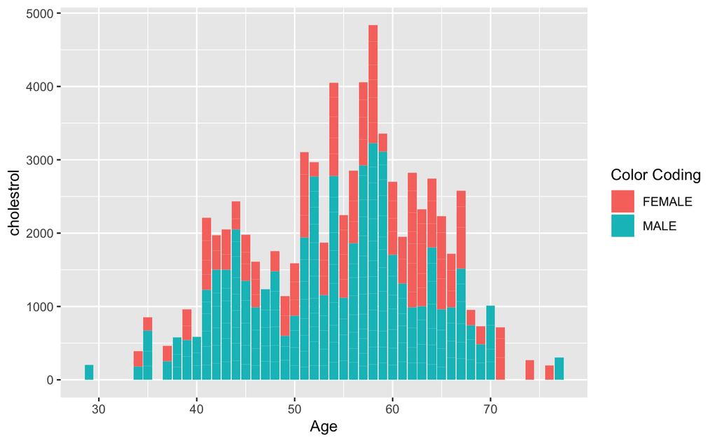

```r
g<-ggplot(data=heart)
g+geom_bar(stat="identity",aes(x=heart$age,y=heart$chol,fill=as.factor(heart$sex)))+xlab("Age")+ylab("cholestrol")+labs(fill="Color Coding")
```

### Representation of Cholestrol level

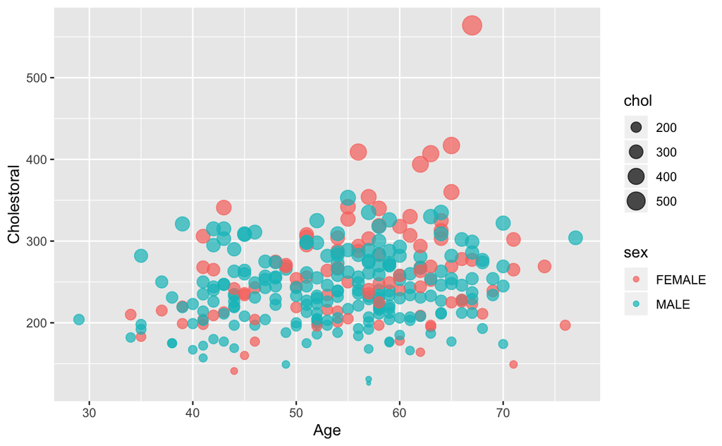

```r
g<-heart %>% ggplot(aes(x=age,y=chol,col=sex, size=chol))+geom_point(alpha=0.7)+xlab("Age") +
           ylab("Cholestoral")+guides(fill = guide_legend(title = "Gender"))
g
```

### Representation of Cholestoral level across different defect conditions

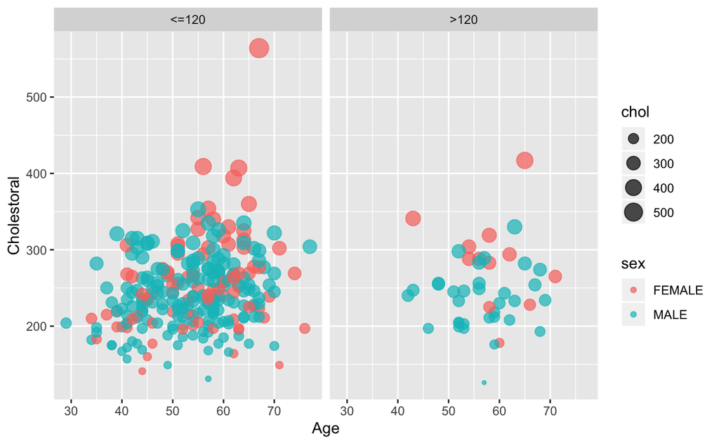

```r
g<-heart %>% ggplot(aes(x=age,y=chol,col=sex, size=chol))+geom_point(alpha=0.7)+xlab("Age") +
           ylab("Cholestoral")+facet_grid(.~fbs)
g
```

### Males vs Females chest pain and the blood pressure they have

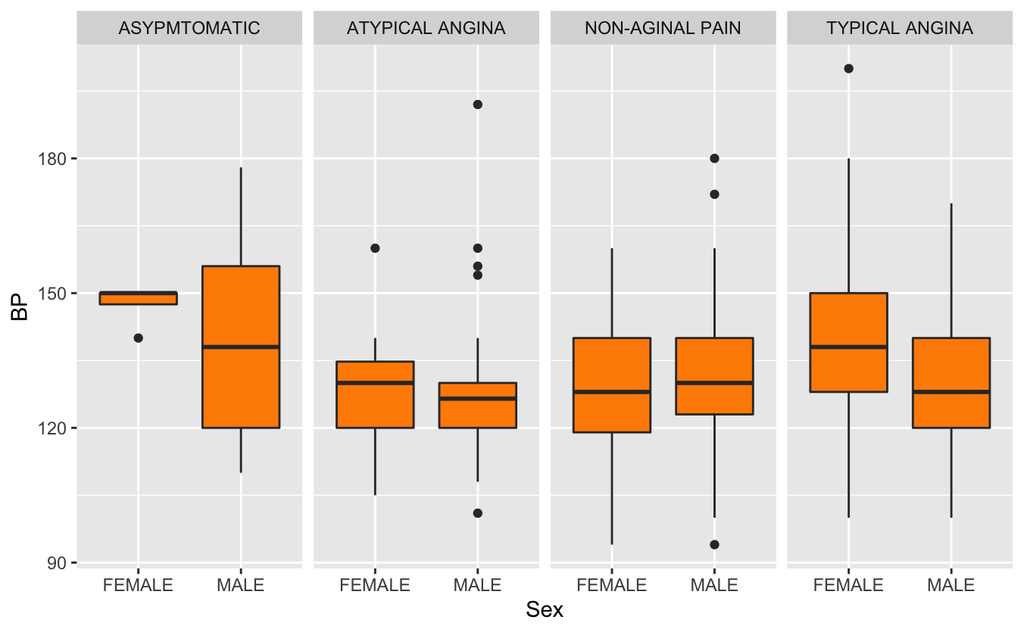

```r
g<-heart%>%ggplot(aes(x=sex,y=trestbps))+geom_boxplot(fill="darkorange")+xlab("Sex")+ylab("BP")+facet_grid(~cp)
g
```

### Machine learning to draw the chance of heart disease depending on other variables

```r
CompleteCases <- heart.data %>%
  select(age,cp,trestbps,chol,fbs,restecg,target) %>%
  na.omit()
CompleteCases %>% nrow()
```

```
[1] 303
```

```r
head(CompleteCases)
```

|  | age | cp | trestbps | chol | fbs | restecg | target |
| --- | --- | --- | --- | --- | --- | --- | --- |
| 1 | 63 | 3 | 145 | 233 | 1 | 0 | 1 |
| 2 | 37 | 2 | 130 | 250 | 0 | 1 | 1 |
| 3 | 41 | 1 | 130 | 204 | 0 | 0 | 1 |
| 4 | 56 | 1 | 120 | 236 | 0 | 1 | 1 |
| 5 | 57 | 0 | 120 | 354 | 0 | 1 | 1 |
| 6 | 57 | 0 | 140 | 192 | 0 | 1 | 1 |

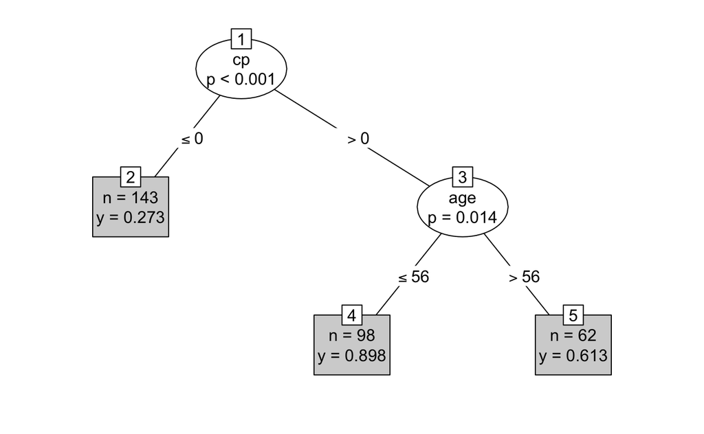

```r
mod1 <- party :: ctree(
  target ~age + cp + chol + fbs + restecg,
  data = CompleteCases
)
plot(mod1, type = "simple")
```

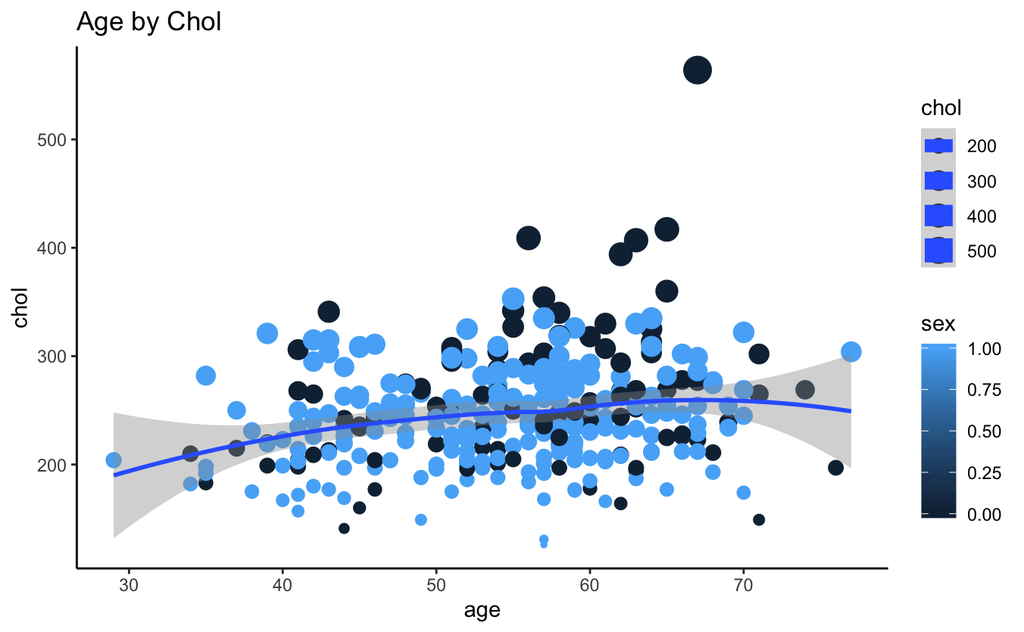

```r
age_point <- ggplot(heart.data, aes(age, chol, color = sex, size = chol))+geom_point()+geom_smooth()+theme_classic()+ggtitle("Age by Chol")
age_point
```

# Key Insight/takeaway about research question

### Looking at the data we were able to say that there is more number of male people suffering from heart diseases than females. We couldnt get conclusive evidence for our second hypothesis of cholestral affects heart disease.

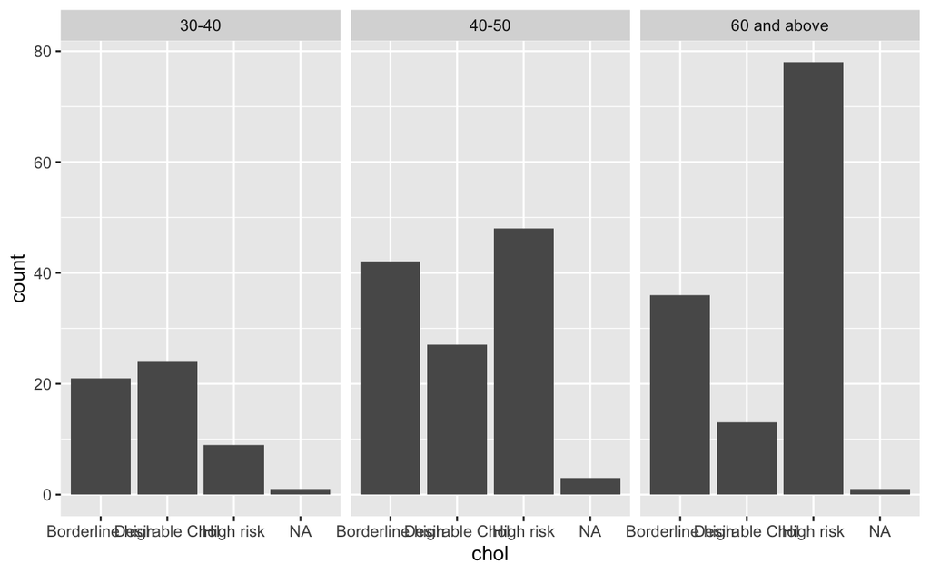

```r
heart2 <- read.csv("framingham.csv")
heart2 <- heart2 %>% select("male","age","totChol")
names(heart2) <- c( "sex", "age","chol")
AgeGroup <- function(age){
  if_else(age <= 30, "20-30",
                       if_else(age <= 40 ,"30-40",
                               if_else(age <= 50,"40-50","60 and above")))
}
set.seed(1)
heart2 <- heart2 %>%
  mutate(sex = if_else(sex == 1, "MALE", "FEMALE"))
heart2 <- heart2 %>% sample_n(303)
heart2.synthesized <- heart2 %>% mutate(chol =LevelOfchol(chol)) %>%
  mutate(age = AgeGroup(age)) %>% group_by(age,chol) %>%
  summarise(count = n())
ggplot(data=heart2.synthesized,aes(x=chol,y=count ))+geom_bar(stat='identity',position='stack', width=.9)+ facet_wrap(~age,ncol=3)
```

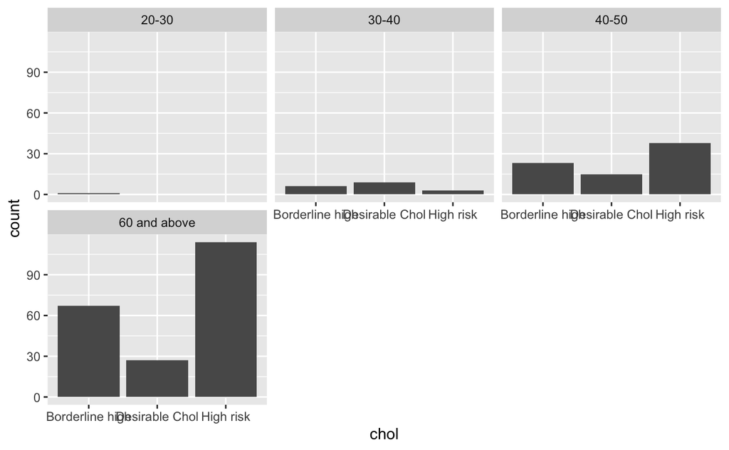

```r
heart.synthesized <- heart %>% mutate(chol = LevelOfchol(chol)) %>%
  mutate(age = AgeGroup(age)) %>% group_by(age,chol) %>%
  summarise(count = n())
ggplot(data=heart.synthesized,aes(x=chol,y=count ))+geom_bar(stat='identity',position='stack', width=.9)+ facet_wrap(~age,ncol=3)
```